# Risk Factor Analysis

## Outcome Variable

**Outcome Variable:** wast_rec90d

## Predictor Variables

**Intervention Variable:** exclfeed3

**Adjustment Set:**

unadjusted

## Stratifying Variables

The analysis was stratified on these variable(s):

- agecat
- studyid
- country

## Data Summary

| agecat | studyid | country | exclfeed3 | wast_rec90d | n_cell | n |
| --- | --- | --- | --- | --- | --- | --- |
| 0-24 months | ki0047075b-MAL-ED | BANGLADESH | 1 | 0 | 32 | 118 |
| 0-24 months | ki0047075b-MAL-ED | BANGLADESH | 1 | 1 | 62 | 118 |
| 0-24 months | ki0047075b-MAL-ED | BANGLADESH | 0 | 0 | 10 | 118 |
| 0-24 months | ki0047075b-MAL-ED | BANGLADESH | 0 | 1 | 14 | 118 |
| 0-24 months | ki0047075b-MAL-ED | BRAZIL | 1 | 0 | 3 | 23 |
| 0-24 months | ki0047075b-MAL-ED | BRAZIL | 1 | 1 | 6 | 23 |
| 0-24 months | ki0047075b-MAL-ED | BRAZIL | 0 | 0 | 3 | 23 |
| 0-24 months | ki0047075b-MAL-ED | BRAZIL | 0 | 1 | 11 | 23 |
| 0-24 months | ki0047075b-MAL-ED | INDIA | 1 | 0 | 34 | 177 |
| 0-24 months | ki0047075b-MAL-ED | INDIA | 1 | 1 | 65 | 177 |
| 0-24 months | ki0047075b-MAL-ED | INDIA | 0 | 0 | 36 | 177 |
| 0-24 months | ki0047075b-MAL-ED | INDIA | 0 | 1 | 42 | 177 |
| 0-24 months | ki0047075b-MAL-ED | NEPAL | 1 | 0 | 6 | 92 |
| 0-24 months | ki0047075b-MAL-ED | NEPAL | 1 | 1 | 21 | 92 |
| 0-24 months | ki0047075b-MAL-ED | NEPAL | 0 | 0 | 14 | 92 |
| 0-24 months | ki0047075b-MAL-ED | NEPAL | 0 | 1 | 51 | 92 |
| 0-24 months | ki0047075b-MAL-ED | PERU | 1 | 0 | 2 | 32 |
| 0-24 months | ki0047075b-MAL-ED | PERU | 1 | 1 | 3 | 32 |
| 0-24 months | ki0047075b-MAL-ED | PERU | 0 | 0 | 4 | 32 |
| 0-24 months | ki0047075b-MAL-ED | PERU | 0 | 1 | 23 | 32 |
| 0-24 months | ki0047075b-MAL-ED | SOUTH AFRICA | 1 | 0 | 1 | 78 |
| 0-24 months | ki0047075b-MAL-ED | SOUTH AFRICA | 1 | 1 | 3 | 78 |
| 0-24 months | ki0047075b-MAL-ED | SOUTH AFRICA | 0 | 0 | 12 | 78 |
| 0-24 months | ki0047075b-MAL-ED | SOUTH AFRICA | 0 | 1 | 62 | 78 |
| 0-24 months | ki0047075b-MAL-ED | TANZANIA, UNITED REPUBLIC OF | 1 | 0 | 1 | 45 |
| 0-24 months | ki0047075b-MAL-ED | TANZANIA, UNITED REPUBLIC OF | 1 | 1 | 12 | 45 |
| 0-24 months | ki0047075b-MAL-ED | TANZANIA, UNITED REPUBLIC OF | 0 | 0 | 7 | 45 |
| 0-24 months | ki0047075b-MAL-ED | TANZANIA, UNITED REPUBLIC OF | 0 | 1 | 25 | 45 |
| 0-24 months | ki1000108-CMC-V-BCS-2002 | INDIA | 1 | 0 | 5 | 11 |
| 0-24 months | ki1000108-CMC-V-BCS-2002 | INDIA | 1 | 1 | 6 | 11 |

[output cut: 162 more lines]

The following strata were considered:

- agecat: 0-24 months, studyid: ki0047075b-MAL-ED, country: BANGLADESH
- agecat: 0-24 months, studyid: ki0047075b-MAL-ED, country: BRAZIL
- agecat: 0-24 months, studyid: ki0047075b-MAL-ED, country: INDIA
- agecat: 0-24 months, studyid: ki0047075b-MAL-ED, country: NEPAL
- agecat: 0-24 months, studyid: ki0047075b-MAL-ED, country: PERU
- agecat: 0-24 months, studyid: ki0047075b-MAL-ED, country: SOUTH AFRICA
- agecat: 0-24 months, studyid: ki0047075b-MAL-ED, country: TANZANIA, UNITED REPUBLIC OF
- agecat: 0-24 months, studyid: ki1000108-CMC-V-BCS-2002, country: INDIA
- agecat: 0-24 months, studyid: ki1000108-IRC, country: INDIA
- agecat: 0-24 months, studyid: ki1000109-EE, country: PAKISTAN
- agecat: 0-24 months, studyid: ki1000304b-SAS-CompFeed, country: INDIA
- agecat: 0-24 months, studyid: ki1017093b-PROVIDE, country: BANGLADESH
- agecat: 0-24 months, studyid: ki1101329-Keneba, country: GAMBIA
- agecat: 0-24 months, studyid: ki1113344-GMS-Nepal, country: NEPAL
- agecat: 0-24 months, studyid: kiGH5241-JiVitA-3, country: BANGLADESH
- agecat: 0-24 months, studyid: kiGH5241-JiVitA-4, country: BANGLADESH
- agecat: 0-6 months, studyid: ki0047075b-MAL-ED, country: BANGLADESH
- agecat: 0-6 months, studyid: ki0047075b-MAL-ED, country: BRAZIL
- agecat: 0-6 months, studyid: ki0047075b-MAL-ED, country: INDIA
- agecat: 0-6 months, studyid: ki0047075b-MAL-ED, country: NEPAL
- agecat: 0-6 months, studyid: ki0047075b-MAL-ED, country: PERU
- agecat: 0-6 months, studyid: ki0047075b-MAL-ED, country: SOUTH AFRICA
- agecat: 0-6 months, studyid: ki0047075b-MAL-ED, country: TANZANIA, UNITED REPUBLIC OF
- agecat: 0-6 months, studyid: ki1000108-CMC-V-BCS-2002, country: INDIA
- agecat: 0-6 months, studyid: ki1000108-IRC, country: INDIA
- agecat: 0-6 months, studyid: ki1000109-EE, country: PAKISTAN
- agecat: 0-6 months, studyid: ki1000304b-SAS-CompFeed, country: INDIA
- agecat: 0-6 months, studyid: ki1017093b-PROVIDE, country: BANGLADESH
- agecat: 0-6 months, studyid: ki1101329-Keneba, country: GAMBIA
- agecat: 0-6 months, studyid: ki1113344-GMS-Nepal, country: NEPAL
- agecat: 0-6 months, studyid: kiGH5241-JiVitA-3, country: BANGLADESH
- agecat: 0-6 months, studyid: kiGH5241-JiVitA-4, country: BANGLADESH
- agecat: 6-24 months, studyid: ki0047075b-MAL-ED, country: BANGLADESH
- agecat: 6-24 months, studyid: ki0047075b-MAL-ED, country: BRAZIL
- agecat: 6-24 months, studyid: ki0047075b-MAL-ED, country: INDIA
- agecat: 6-24 months, studyid: ki0047075b-MAL-ED, country: NEPAL
- agecat: 6-24 months, studyid: ki0047075b-MAL-ED, country: PERU
- agecat: 6-24 months, studyid: ki0047075b-MAL-ED, country: SOUTH AFRICA
- agecat: 6-24 months, studyid: ki0047075b-MAL-ED, country: TANZANIA, UNITED REPUBLIC OF
- agecat: 6-24 months, studyid: ki1000108-CMC-V-BCS-2002, country: INDIA
- agecat: 6-24 months, studyid: ki1000108-IRC, country: INDIA
- agecat: 6-24 months, studyid: ki1000109-EE, country: PAKISTAN
- agecat: 6-24 months, studyid: ki1000304b-SAS-CompFeed, country: INDIA
- agecat: 6-24 months, studyid: ki1017093b-PROVIDE, country: BANGLADESH
- agecat: 6-24 months, studyid: ki1101329-Keneba, country: GAMBIA
- agecat: 6-24 months, studyid: ki1113344-GMS-Nepal, country: NEPAL
- agecat: 6-24 months, studyid: kiGH5241-JiVitA-3, country: BANGLADESH
- agecat: 6-24 months, studyid: kiGH5241-JiVitA-4, country: BANGLADESH

### Dropped Strata

Some strata were dropped due to rare outcomes:

- agecat: 0-24 months, studyid: ki0047075b-MAL-ED, country: BRAZIL
- agecat: 0-24 months, studyid: ki0047075b-MAL-ED, country: PERU
- agecat: 0-24 months, studyid: ki0047075b-MAL-ED, country: SOUTH AFRICA
- agecat: 0-24 months, studyid: ki0047075b-MAL-ED, country: TANZANIA, UNITED REPUBLIC OF
- agecat: 0-24 months, studyid: ki1000108-CMC-V-BCS-2002, country: INDIA
- agecat: 0-24 months, studyid: ki1000108-IRC, country: INDIA
- agecat: 0-24 months, studyid: ki1000109-EE, country: PAKISTAN
- agecat: 0-24 months, studyid: ki1000304b-SAS-CompFeed, country: INDIA
- agecat: 0-24 months, studyid: kiGH5241-JiVitA-4, country: BANGLADESH
- agecat: 0-6 months, studyid: ki0047075b-MAL-ED, country: BANGLADESH
- agecat: 0-6 months, studyid: ki0047075b-MAL-ED, country: BRAZIL
- agecat: 0-6 months, studyid: ki0047075b-MAL-ED, country: NEPAL
- agecat: 0-6 months, studyid: ki0047075b-MAL-ED, country: PERU
- agecat: 0-6 months, studyid: ki0047075b-MAL-ED, country: SOUTH AFRICA
- agecat: 0-6 months, studyid: ki0047075b-MAL-ED, country: TANZANIA, UNITED REPUBLIC OF
- agecat: 0-6 months, studyid: ki1000108-CMC-V-BCS-2002, country: INDIA
- agecat: 0-6 months, studyid: ki1000108-IRC, country: INDIA
- agecat: 0-6 months, studyid: ki1000109-EE, country: PAKISTAN
- agecat: 0-6 months, studyid: ki1000304b-SAS-CompFeed, country: INDIA
- agecat: 0-6 months, studyid: kiGH5241-JiVitA-4, country: BANGLADESH
- agecat: 6-24 months, studyid: ki0047075b-MAL-ED, country: BANGLADESH
- agecat: 6-24 months, studyid: ki0047075b-MAL-ED, country: BRAZIL
- agecat: 6-24 months, studyid: ki0047075b-MAL-ED, country: NEPAL
- agecat: 6-24 months, studyid: ki0047075b-MAL-ED, country: PERU
- agecat: 6-24 months, studyid: ki0047075b-MAL-ED, country: SOUTH AFRICA
- agecat: 6-24 months, studyid: ki0047075b-MAL-ED, country: TANZANIA, UNITED REPUBLIC OF
- agecat: 6-24 months, studyid: ki1000108-CMC-V-BCS-2002, country: INDIA
- agecat: 6-24 months, studyid: ki1000108-IRC, country: INDIA
- agecat: 6-24 months, studyid: ki1000109-EE, country: PAKISTAN
- agecat: 6-24 months, studyid: ki1000304b-SAS-CompFeed, country: INDIA
- agecat: 6-24 months, studyid: kiGH5241-JiVitA-3, country: BANGLADESH
- agecat: 6-24 months, studyid: kiGH5241-JiVitA-4, country: BANGLADESH

## Methods Detail

We’re interested in the causal parameters $E[Y_a]$ for all values of $a \in \mathcal{A}$. These parameters represent the mean outcome if, possibly contrary to fact, we intervened to set all units to have $A=a$. Under the randomization and positivity assumptions, these are identified by the statistical parameters $\psi_a=E_W[E_{Y|A,W}(Y|A=a,W)]$. In addition, we’re interested in the mean of $Y$, $E[Y]$ under no intervention (the observed mean). We will estimate these parameters by using SuperLearner to fit the relevant likelihood factors – $E_{Y|A,W}(Y|A=a,W)$ and $p(A=a|W)$, and then updating our likelihood fit using a joint TMLE.

For unadjusted analyses ($W=\{\}$), initial likelihoods were estimated using Lrnr_glm to estimate the simple $E(Y|A)$ and Lrnr_mean to estimate $p(A)$. For adjusted analyses, a small library containing Lrnr_glmnet, Lrnr_xgboost, and Lrnr_mean was used.

Having estimated these parameters, we will then use the delta method to estimate relative risks and attributable risks relative to a prespecified baseline level of $A$.

# Results Detail

## Results Plots

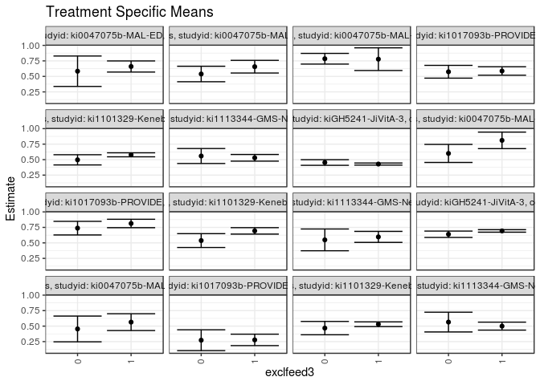

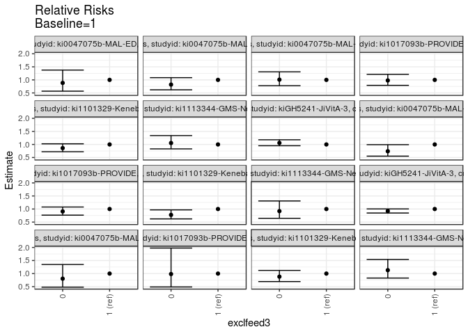

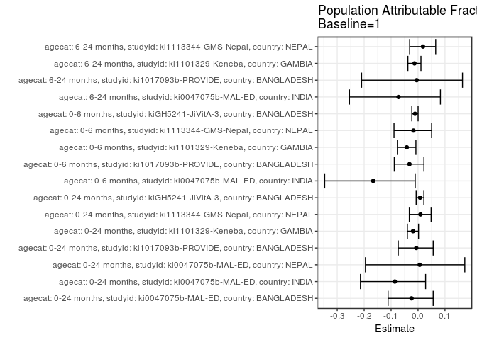

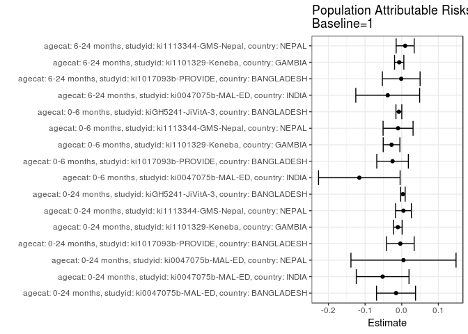

## Results Table

### Parameter: TSM

| agecat | studyid | country | intervention_level | baseline_level | estimate | ci_lower | ci_upper |
| --- | --- | --- | --- | --- | --- | --- | --- |
| 0-24 months | ki0047075b-MAL-ED | BANGLADESH | 1 | NA | 0.6595745 | 0.5700476 | 0.7491014 |
| 0-24 months | ki0047075b-MAL-ED | BANGLADESH | 0 | NA | 0.5833333 | 0.3380231 | 0.8286436 |
| 0-24 months | ki0047075b-MAL-ED | INDIA | 1 | NA | 0.6565657 | 0.5545252 | 0.7586061 |
| 0-24 months | ki0047075b-MAL-ED | INDIA | 0 | NA | 0.5384615 | 0.4134804 | 0.6634427 |
| 0-24 months | ki0047075b-MAL-ED | NEPAL | 1 | NA | 0.7777778 | 0.5946691 | 0.9608864 |
| 0-24 months | ki0047075b-MAL-ED | NEPAL | 0 | NA | 0.7846154 | 0.6984506 | 0.8707802 |
| 0-24 months | ki1017093b-PROVIDE | BANGLADESH | 1 | NA | 0.5868545 | 0.5186588 | 0.6550502 |
| 0-24 months | ki1017093b-PROVIDE | BANGLADESH | 0 | NA | 0.5744681 | 0.4715248 | 0.6774114 |
| 0-24 months | ki1101329-Keneba | GAMBIA | 1 | NA | 0.5778192 | 0.5455846 | 0.6100538 |
| 0-24 months | ki1101329-Keneba | GAMBIA | 0 | NA | 0.4968944 | 0.4144002 | 0.5793886 |
| 0-24 months | ki1113344-GMS-Nepal | NEPAL | 1 | NA | 0.5292621 | 0.4753470 | 0.5831772 |
| 0-24 months | ki1113344-GMS-Nepal | NEPAL | 0 | NA | 0.5584416 | 0.4376550 | 0.6792281 |
| 0-24 months | kiGH5241-JiVitA-3 | BANGLADESH | 1 | NA | 0.4286155 | 0.4116329 | 0.4455980 |
| 0-24 months | kiGH5241-JiVitA-3 | BANGLADESH | 0 | NA | 0.4537815 | 0.4085910 | 0.4989721 |
| 0-6 months | ki0047075b-MAL-ED | INDIA | 1 | NA | 0.8108108 | 0.6777087 | 0.9439129 |
| 0-6 months | ki0047075b-MAL-ED | INDIA | 0 | NA | 0.6000000 | 0.4545320 | 0.7454680 |
| 0-6 months | ki1017093b-PROVIDE | BANGLADESH | 1 | NA | 0.8130081 | 0.7450537 | 0.8809625 |
| 0-6 months | ki1017093b-PROVIDE | BANGLADESH | 0 | NA | 0.7377049 | 0.6278629 | 0.8475469 |
| 0-6 months | ki1101329-Keneba | GAMBIA | 1 | NA | 0.6935484 | 0.6415100 | 0.7455868 |
| 0-6 months | ki1101329-Keneba | GAMBIA | 0 | NA | 0.5373134 | 0.4257369 | 0.6488899 |
| 0-6 months | ki1113344-GMS-Nepal | NEPAL | 1 | NA | 0.5966387 | 0.5078041 | 0.6854732 |
| 0-6 months | ki1113344-GMS-Nepal | NEPAL | 0 | NA | 0.5483871 | 0.3726315 | 0.7241427 |
| 0-6 months | kiGH5241-JiVitA-3 | BANGLADESH | 1 | NA | 0.6929212 | 0.6727351 | 0.7131074 |
| 0-6 months | kiGH5241-JiVitA-3 | BANGLADESH | 0 | NA | 0.6390533 | 0.5878193 | 0.6902872 |
| 6-24 months | ki0047075b-MAL-ED | INDIA | 1 | NA | 0.5645161 | 0.4290709 | 0.6999613 |
| 6-24 months | ki0047075b-MAL-ED | INDIA | 0 | NA | 0.4545455 | 0.2469787 | 0.6621122 |
| 6-24 months | ki1017093b-PROVIDE | BANGLADESH | 1 | NA | 0.2777778 | 0.1853143 | 0.3702413 |
| 6-24 months | ki1017093b-PROVIDE | BANGLADESH | 0 | NA | 0.2727273 | 0.1045711 | 0.4408835 |
| 6-24 months | ki1101329-Keneba | GAMBIA | 1 | NA | 0.5307995 | 0.4929067 | 0.5686923 |
| 6-24 months | ki1101329-Keneba | GAMBIA | 0 | NA | 0.4680851 | 0.3606539 | 0.5755163 |
| 6-24 months | ki1113344-GMS-Nepal | NEPAL | 1 | NA | 0.5000000 | 0.4354869 | 0.5645131 |
| 6-24 months | ki1113344-GMS-Nepal | NEPAL | 0 | NA | 0.5652174 | 0.4059418 | 0.7244930 |

### Parameter: E(Y)

| agecat | studyid | country | intervention_level | baseline_level | estimate | ci_lower | ci_upper |
| --- | --- | --- | --- | --- | --- | --- | --- |
| 0-24 months | ki0047075b-MAL-ED | BANGLADESH | NA | NA | 0.6440678 | 0.5565826 | 0.7315530 |
| 0-24 months | ki0047075b-MAL-ED | INDIA | NA | NA | 0.6045198 | 0.5246128 | 0.6844268 |
| 0-24 months | ki0047075b-MAL-ED | NEPAL | NA | NA | 0.7826087 | 0.7016344 | 0.8635829 |
| 0-24 months | ki1017093b-PROVIDE | BANGLADESH | NA | NA | 0.5830619 | 0.5262762 | 0.6398476 |
| 0-24 months | ki1101329-Keneba | GAMBIA | NA | NA | 0.5672609 | 0.5371792 | 0.5973426 |
| 0-24 months | ki1113344-GMS-Nepal | NEPAL | NA | NA | 0.5340426 | 0.4848509 | 0.5832342 |
| 0-24 months | kiGH5241-JiVitA-3 | BANGLADESH | NA | NA | 0.4318365 | 0.4159351 | 0.4477379 |
| 0-6 months | ki0047075b-MAL-ED | INDIA | NA | NA | 0.6951220 | 0.5922224 | 0.7980215 |
| 0-6 months | ki1017093b-PROVIDE | BANGLADESH | NA | NA | 0.7880435 | 0.7295878 | 0.8464992 |
| 0-6 months | ki1101329-Keneba | GAMBIA | NA | NA | 0.6657825 | 0.6181920 | 0.7133730 |
| 0-6 months | ki1113344-GMS-Nepal | NEPAL | NA | NA | 0.5866667 | 0.5072781 | 0.6660552 |
| 0-6 months | kiGH5241-JiVitA-3 | BANGLADESH | NA | NA | 0.6851536 | 0.6663491 | 0.7039581 |
| 6-24 months | ki0047075b-MAL-ED | INDIA | NA | NA | 0.5263158 | 0.4116286 | 0.6410029 |
| 6-24 months | ki1017093b-PROVIDE | BANGLADESH | NA | NA | 0.2764228 | 0.1950773 | 0.3577682 |
| 6-24 months | ki1101329-Keneba | GAMBIA | NA | NA | 0.5239207 | 0.4881434 | 0.5596979 |
| 6-24 months | ki1113344-GMS-Nepal | NEPAL | NA | NA | 0.5093750 | 0.4496016 | 0.5691484 |

### Parameter: RR

| agecat | studyid | country | intervention_level | baseline_level | estimate | ci_lower | ci_upper |
| --- | --- | --- | --- | --- | --- | --- | --- |
| 0-24 months | ki0047075b-MAL-ED | BANGLADESH | 1 | 1 | 1.0000000 | 1.0000000 | 1.0000000 |
| 0-24 months | ki0047075b-MAL-ED | BANGLADESH | 0 | 1 | 0.8844086 | 0.5683707 | 1.3761769 |
| 0-24 months | ki0047075b-MAL-ED | INDIA | 1 | 1 | 1.0000000 | 1.0000000 | 1.0000000 |
| 0-24 months | ki0047075b-MAL-ED | INDIA | 0 | 1 | 0.8201183 | 0.6202486 | 1.0843944 |
| 0-24 months | ki0047075b-MAL-ED | NEPAL | 1 | 1 | 1.0000000 | 1.0000000 | 1.0000000 |
| 0-24 months | ki0047075b-MAL-ED | NEPAL | 0 | 1 | 1.0087912 | 0.7775396 | 1.3088204 |
| 0-24 months | ki1017093b-PROVIDE | BANGLADESH | 1 | 1 | 1.0000000 | 1.0000000 | 1.0000000 |
| 0-24 months | ki1017093b-PROVIDE | BANGLADESH | 0 | 1 | 0.9788936 | 0.7904992 | 1.2121868 |
| 0-24 months | ki1101329-Keneba | GAMBIA | 1 | 1 | 1.0000000 | 1.0000000 | 1.0000000 |
| 0-24 months | ki1101329-Keneba | GAMBIA | 0 | 1 | 0.8599479 | 0.7217837 | 1.0245596 |
| 0-24 months | ki1113344-GMS-Nepal | NEPAL | 1 | 1 | 1.0000000 | 1.0000000 | 1.0000000 |
| 0-24 months | ki1113344-GMS-Nepal | NEPAL | 0 | 1 | 1.0551324 | 0.8306696 | 1.3402492 |
| 0-24 months | kiGH5241-JiVitA-3 | BANGLADESH | 1 | 1 | 1.0000000 | 1.0000000 | 1.0000000 |
| 0-24 months | kiGH5241-JiVitA-3 | BANGLADESH | 0 | 1 | 1.0587147 | 0.9511118 | 1.1784911 |
| 0-6 months | ki0047075b-MAL-ED | INDIA | 1 | 1 | 1.0000000 | 1.0000000 | 1.0000000 |
| 0-6 months | ki0047075b-MAL-ED | INDIA | 0 | 1 | 0.7400000 | 0.5521528 | 0.9917544 |
| 0-6 months | ki1017093b-PROVIDE | BANGLADESH | 1 | 1 | 1.0000000 | 1.0000000 | 1.0000000 |
| 0-6 months | ki1017093b-PROVIDE | BANGLADESH | 0 | 1 | 0.9073770 | 0.7649426 | 1.0763332 |
| 0-6 months | ki1101329-Keneba | GAMBIA | 1 | 1 | 1.0000000 | 1.0000000 | 1.0000000 |
| 0-6 months | ki1101329-Keneba | GAMBIA | 0 | 1 | 0.7747310 | 0.6212423 | 0.9661417 |
| 0-6 months | ki1113344-GMS-Nepal | NEPAL | 1 | 1 | 1.0000000 | 1.0000000 | 1.0000000 |
| 0-6 months | ki1113344-GMS-Nepal | NEPAL | 0 | 1 | 0.9191277 | 0.6455067 | 1.3087327 |
| 0-6 months | kiGH5241-JiVitA-3 | BANGLADESH | 1 | 1 | 1.0000000 | 1.0000000 | 1.0000000 |
| 0-6 months | kiGH5241-JiVitA-3 | BANGLADESH | 0 | 1 | 0.9222596 | 0.8468523 | 1.0043815 |
| 6-24 months | ki0047075b-MAL-ED | INDIA | 1 | 1 | 1.0000000 | 1.0000000 | 1.0000000 |
| 6-24 months | ki0047075b-MAL-ED | INDIA | 0 | 1 | 0.8051948 | 0.4807026 | 1.3487313 |
| 6-24 months | ki1017093b-PROVIDE | BANGLADESH | 1 | 1 | 1.0000000 | 1.0000000 | 1.0000000 |
| 6-24 months | ki1017093b-PROVIDE | BANGLADESH | 0 | 1 | 0.9818182 | 0.4873998 | 1.9777746 |
| 6-24 months | ki1101329-Keneba | GAMBIA | 1 | 1 | 1.0000000 | 1.0000000 | 1.0000000 |
| 6-24 months | ki1101329-Keneba | GAMBIA | 0 | 1 | 0.8818492 | 0.6934118 | 1.1214953 |
| 6-24 months | ki1113344-GMS-Nepal | NEPAL | 1 | 1 | 1.0000000 | 1.0000000 | 1.0000000 |
| 6-24 months | ki1113344-GMS-Nepal | NEPAL | 0 | 1 | 1.1304348 | 0.8289337 | 1.5415983 |

### Parameter: PAR

| agecat | studyid | country | intervention_level | baseline_level | estimate | ci_lower | ci_upper |
| --- | --- | --- | --- | --- | --- | --- | --- |
| 0-24 months | ki0047075b-MAL-ED | BANGLADESH | 1 | NA | -0.0155067 | -0.0687695 | 0.0377562 |
| 0-24 months | ki0047075b-MAL-ED | INDIA | 1 | NA | -0.0520459 | -0.1239998 | 0.0199081 |
| 0-24 months | ki0047075b-MAL-ED | NEPAL | 1 | NA | 0.0048309 | -0.1385574 | 0.1482192 |
| 0-24 months | ki1017093b-PROVIDE | BANGLADESH | 1 | NA | -0.0037926 | -0.0415794 | 0.0339942 |
| 0-24 months | ki1101329-Keneba | GAMBIA | 1 | NA | -0.0105583 | -0.0222899 | 0.0011734 |
| 0-24 months | ki1113344-GMS-Nepal | NEPAL | 1 | NA | 0.0047805 | -0.0168161 | 0.0263770 |
| 0-24 months | kiGH5241-JiVitA-3 | BANGLADESH | 1 | NA | 0.0032210 | -0.0029641 | 0.0094061 |
| 0-6 months | ki0047075b-MAL-ED | INDIA | 1 | NA | -0.1156889 | -0.2269651 | -0.0044126 |
| 0-6 months | ki1017093b-PROVIDE | BANGLADESH | 1 | NA | -0.0249647 | -0.0680442 | 0.0181149 |
| 0-6 months | ki1101329-Keneba | GAMBIA | 1 | NA | -0.0277659 | -0.0505034 | -0.0050284 |
| 0-6 months | ki1113344-GMS-Nepal | NEPAL | 1 | NA | -0.0099720 | -0.0508653 | 0.0309213 |
| 0-6 months | kiGH5241-JiVitA-3 | BANGLADESH | 1 | NA | -0.0077677 | -0.0157451 | 0.0002098 |
| 6-24 months | ki0047075b-MAL-ED | INDIA | 1 | NA | -0.0382003 | -0.1253112 | 0.0489105 |
| 6-24 months | ki1017093b-PROVIDE | BANGLADESH | 1 | NA | -0.0013550 | -0.0528032 | 0.0500932 |
| 6-24 months | ki1101329-Keneba | GAMBIA | 1 | NA | -0.0068788 | -0.0195572 | 0.0057995 |
| 6-24 months | ki1113344-GMS-Nepal | NEPAL | 1 | NA | 0.0093750 | -0.0152276 | 0.0339776 |

### Parameter: PAF

| agecat | studyid | country | intervention_level | baseline_level | estimate | ci_lower | ci_upper |
| --- | --- | --- | --- | --- | --- | --- | --- |
| 0-24 months | ki0047075b-MAL-ED | BANGLADESH | 1 | NA | -0.0240761 | -0.1112112 | 0.0562262 |
| 0-24 months | ki0047075b-MAL-ED | INDIA | 1 | NA | -0.0860946 | -0.2137539 | 0.0281379 |
| 0-24 months | ki0047075b-MAL-ED | NEPAL | 1 | NA | 0.0061728 | -0.1952351 | 0.1736417 |
| 0-24 months | ki1017093b-PROVIDE | BANGLADESH | 1 | NA | -0.0065046 | -0.0734476 | 0.0562637 |
| 0-24 months | ki1101329-Keneba | GAMBIA | 1 | NA | -0.0186127 | -0.0395343 | 0.0018878 |
| 0-24 months | ki1113344-GMS-Nepal | NEPAL | 1 | NA | 0.0089515 | -0.0323417 | 0.0485930 |
| 0-24 months | kiGH5241-JiVitA-3 | BANGLADESH | 1 | NA | 0.0074589 | -0.0069666 | 0.0216778 |
| 0-6 months | ki0047075b-MAL-ED | INDIA | 1 | NA | -0.1664296 | -0.3465073 | -0.0104349 |
| 0-6 months | ki1017093b-PROVIDE | BANGLADESH | 1 | NA | -0.0316793 | -0.0881944 | 0.0219007 |
| 0-6 months | ki1101329-Keneba | GAMBIA | 1 | NA | -0.0417042 | -0.0766604 | -0.0078828 |
| 0-6 months | ki1113344-GMS-Nepal | NEPAL | 1 | NA | -0.0169977 | -0.0892186 | 0.0504346 |
| 0-6 months | kiGH5241-JiVitA-3 | BANGLADESH | 1 | NA | -0.0113371 | -0.0230622 | 0.0002536 |
| 6-24 months | ki0047075b-MAL-ED | INDIA | 1 | NA | -0.0725806 | -0.2546184 | 0.0830445 |
| 6-24 months | ki1017093b-PROVIDE | BANGLADESH | 1 | NA | -0.0049020 | -0.2095297 | 0.1651070 |
| 6-24 months | ki1101329-Keneba | GAMBIA | 1 | NA | -0.0131295 | -0.0376417 | 0.0108036 |
| 6-24 months | ki1113344-GMS-Nepal | NEPAL | 1 | NA | 0.0184049 | -0.0311409 | 0.0655701 |